# Practical Machine Learning Project

Irene Mommers

2026-01-13

Data was downloaded and stored into the working directory. I will use the ‘pml-training.csv’ to partition in a training and test dataset, where the trainingset will be used for development of seperate models, and the trainingset to fit those models and combine them into one predictor. The other dataset (‘pml-testing.csv’) will be used as validationset and thus not be touched before application of the final model in the end.

## Read and explore dat

```r
# load data
dat = read.csv("pml-training.csv")

# partition
inBuild <- createDataPartition(y=dat$classe, p=0.75, list=FALSE)
train <- dat[inBuild,]
test  <- dat[-inBuild,]

# set seed for reproducibility
set.seed(75129)

# inspect size of train and test data
dim(train); dim(test)
```

```
## [1] 14718   160
```

```
## [1] 4904  160
```

At first glance, 19622 observation and 160 variables means that there are plenty of observations per variable, yet it might still be good to cut down the number of variables to include in the model, to prevent overfitting.

Looking at the data (View(train)), it is noticable that there appears to be loads of missingness in some variables and that some variables show little variation. Also, there are time-stamp variables and a character with the date and time - this last one can be removed as it is non-informative as compared to the others.

```r
# set outcome variable to factor
train$classe <- as.factor(train$classe)

# Remove id and timestamps/windows as these will probably not be predictive
train <- train %>% select(-X,-user_name,-raw_timestamp_part_1,
-raw_timestamp_part_2,-cvtd_timestamp,-new_window,-num_window)

# explore missingness
table(colSums(is.na(train)))
```

```
##
##     0 14409
##    86    67
```

```r
# drop variables with >95% missing
train <- train[,!((colSums(is.na(train))/nrow(train))>0.95)]
dim(train)
```

```
## [1] 14718    86
```

```r
# explore near-zero variance
nsv <- nearZeroVar(train, saveMetrics=TRUE)

# drop variables from train with
train <- train[,!(unlist(nsv$nzv))]
dim(train)
```

```
## [1] 14718    53
```

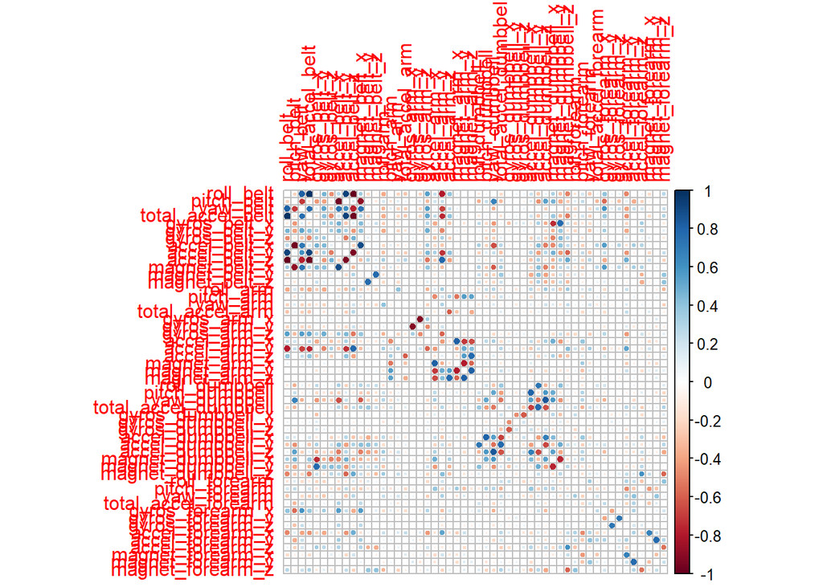

```r
# explore correlatedness of numeric variables
num <- train[,sapply(train,is.numeric)] # obtain numeric columns
num <- as.data.frame(sapply(num, scale)) # scale variables
cor.table <- cor(num)
diag(cor.table) <-  0 # set the diagonal to 0
corrplot(cor.table)
```

```r
which(cor.table > 0.8, arr.ind=T)
```

```
##                  row col
## yaw_belt           3   1
## total_accel_belt   4   1
## accel_belt_y       9   1
## roll_belt          1   3
## roll_belt          1   4
## accel_belt_y       9   4
## magnet_belt_x     11   8
## roll_belt          1   9
## total_accel_belt   4   9
## accel_belt_x       8  11
## magnet_arm_x      24  21
## accel_arm_x       21  24
## magnet_arm_z      26  25
## magnet_arm_y      25  26
## accel_dumbbell_x  34  28
## accel_dumbbell_z  36  29
## pitch_dumbbell    28  34
## yaw_dumbbell      29  36
```